# Magnetostatic field

```python
from IPython.display import YouTubeVideo
```

Magnetostatic field

Class notes for Physics for computer science and AI.

1. Electric current
2. Ohm's law
3. Electromotive force
4. Magnetic force
5. Magnetic field
6. Magnetic flux
7. Gauss's law for magnetism
8. Ampere's circuital law
9. Magnetic dipole
10. Magnetic materials
11. The Hall effect

**Recommended readings**

- Sears and Zemansky's University physics-Addison Wesley (I will mostly follow this book, many figures in these slides taken from it)
  - Chapters 25,27,28

# 1. Electric current

An electric current is simply a motion of electric charge in space, thus one could define it as a local variation of charge $Q(\vec x)$ in time

| $$I=\frac{d Q}{d t}$$ |
| --- |

Intuitively, the charge in a certain region of space increases when there is current **flowing in** (so $dQ/dt>0$)

Alternatively, we could say that electric current is a **net flow of charge**. Mathematically, we define the current as the net charge flowing through a cross-sectional area per unit time.

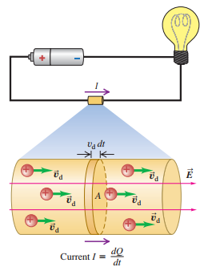

$d Q=q\left(n A v_{\mathrm{d}} d t\right)$

Hence,

| $$I=\frac{d Q}{d t}=n q v_{\mathrm{d}} A$$ |
| --- |

- $n$: concentration of particles per unit volume ($m^{-3}$)
- $v_{\mathrm{d}}$: velocity of the particles ($m/s$)
- $A$ cross-sectional area ($m^2$)
- $q$ charge of a single particle.

*Remarks*

- Current is not a vector quantity, but a **scalar** quantity.
- The SI unit of current is the **ampere**, in honor of André Marie Ampère (1775–1836), defined as one coulomb per second $1 \mathrm{A}=1 \mathrm{C} / \mathrm{s}$
- When the charge is constrained to follow a conducting path, it is called an **electric circuit**. In a circuit, current is always along the length of the wire, regardless of its shape.
- Electric currents move **energy** in space. Electric circuits are therefore useful to transport energy in a controlled fashion.
- Electric currents are everywhere: computers, biological nervous systems, global atmospheric electrical circuit...
- In normal DC circuits, currents are of the order of milliamperes ($1mA=10^{-3}A)$ or ($1\mu A=10^{-6}A)$. Currents for engines, machinery, etc, in the ampere range. Current in computer circuits, in the range of nanoamperes ($1nA=10^{-9}A)$ or picoamperes ($1pA=10^{-12}A)$.
- A conductor may contain different kinds of moving charged particles with different signs (electrons, positive ions, holes...), but all of the **add up** to the net current.
- Current is not used up or along the circuit, but energy is!

## 1.1 Vector current density

Knowing what the current is, alternative ways to define the vector current density are

| $$\vec{J}=n q \vec v_{\mathrm{d}}$$ |
| --- |

$$|\vec J||=\frac{I}{A}$$$$I=\int_{S} \vec{J} \cdot \vec{n} d S$$

*Properties*

- Current density is a **vector**! even though the current is a scalar.
- SI unit is $A/m^2$
- Its direction indicates the **conventional** flow of charge, and its magnitude the current per unit surface.
- Bearing in mind the expression for the electric flux, current would be like the flux for the current density.

## 1.2 Model of metallic conduction

Free electrons move randomly in a conductor, like a **gas** made of electrons, travelling at $\approx 10^6m/s$. Nonetheless, there is no net flow of charge in any direction.

Now suppose we establish a constant field $\vec E$ inside the conductor, so the electrons will experience a constant force $\vec F=q\vec E$. In free space, this force would cause that particles to describe a uniformly accelerated linear motion; however, electrons frequently collide with the positive ions of the conductor. In each collision the direction randomly changes, but there is also a very slow net motion or drift, described by the **drift velocity** $\vec v_{\mathrm{d}}$ on the order of $\approx 10^{-4}m/s$. In a circuit, the electric field (which travels at the speed of light) is established along the circuit almost immediately, that's why electrons start to move all along the wire at very nearly the same time. The electric force then does a work on the moving charges. Part of the kinetic energy is transfered to the conductor through collisions, causing ions in the conductor to vibrate (perceived as the conductor heating up).

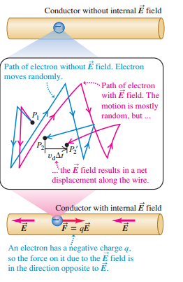

- if q is positive $\vec v_{\mathrm{d}}$ lies in the same direction as $\vec E$
- if q is negative $\vec v_{\mathrm{d}}$ is in the opposite direction as $\vec E$
- In both cases $\vec{J}$ shares direction with $\vec E$|

```python
YouTubeVideo('8Posj4WMo0o')
```

[video not shown]

## 1.3 Continuity equation

The amount of charge $q$ in a region increases or decreases because $q$ flows inward or outward through a surface $S$ (real or imaginary) enclosing that region. $q$ must be conserved!

$$\frac{d q}{d t}=-\oint_{S} \vec{J} \cdot d \vec{S} \label{continuity}$$

Another possibility is that $q$ increases or decreases due to a source or sink of $q$ in the region. Let $\Sigma$ be the net rate at which $q$ is generated ($\Sigma>0$) or destroyed ( $\Sigma<0$) in the volume $V$ enclosed by the surface $S$. Then

$$\frac{d q}{d t}=-\oint_{S} \vec{J} \cdot d \vec{S}+\Sigma$$

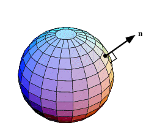

Using the divergence theorem (beyond the scope of this course), it is straightforward to show that the continuity equation can be written in differential form as

$$\frac{\partial \rho}{\partial t}+\nabla \cdot \vec{J}=G$$

where $\nabla \cdot \vec{J}$ is the divergence of the vector field $\vec J$

$$\nabla \cdot \vec{J}=\frac{\partial J_{x}}{\partial x}+\frac{\partial J_{y}}{\partial y}+\frac{\partial J_{z}}{\partial z}$$

and $G$ is the generation (destruction) of $q$ per unit volume per unit time.

In 1D the equation reduces to

| $$\frac{\partial \rho}{\partial t}+\frac{\partial J_{x}}{\partial x}=G$$ |
| --- |

# 2. Ohm's law

Once the conduction is established, what is the relation between the current density and the electric field causing such current density? The Ohm's law tells us that the relation is linear

$$ \vec E=\rho \vec J$$

*Remarks*

- Good approximation for metals. A material that obeys Ohm's law is called Ohmic. Many are non-Ohmic (like diodes)
- $\rho$ is called **resistivity**, measured in $(\mathrm{V} / \mathrm{m}) /\left(\mathrm{A} / \mathrm{m}^{2}\right)=\mathrm{V} \cdot \mathrm{m} / \mathrm{A}=\Omega \cdot\mathrm{m}$. It characterizes the intrinsic resistance to a electric current. Same symbol as volume density charge, do not confuse them!!!
- The reciprocal of resistivity is **conductivity**.
- Poor electrical conductors (ceramics, plastics) are normally poor thermal conductors as well, as particles are nor free to transport any form of energy.

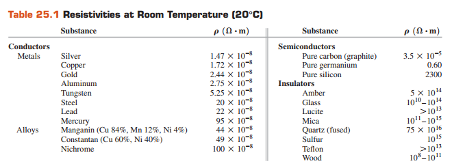

## 2.1 Resistance

Ohm's law can be re-expressed in a more convenient form. Let's assume the conductor is a long wire of length $L$ and cross-section area $A$. Let $V$ potential difference between the extremes of the wire, and $I$ the current flowing within. As $\vec J$ and $\vec E$ are constant and parallel along the wire, we can write $I=JA$ and $V=EL$, hence

| $$ V=\frac{\rho L}{A} I=RI$$ |
| --- |

*Properties*

- $R=V/I$ is called **resistance**, measured in Ohms ($\Omega=V/A$). Unlike the resistivity, it is not an intrinsic quantity of the material as it also depends on the **geometry**.
- Typical values in circuits $\Omega$, kilohms, $k\Omega=10^{3}\Omega$, megaohms $M\Omega=10^{6}\Omega$
- Resistance varies with temperature, the simples model is linear $R(T)\approx R_{0}\left[1+\alpha\left(T-T_{0}\right)\right]$.
- A circuit component made to have a specific value of resistance is called a **resistor**.

In practice, real resistors of different values are used to limit the current in a certain part of the circuit.

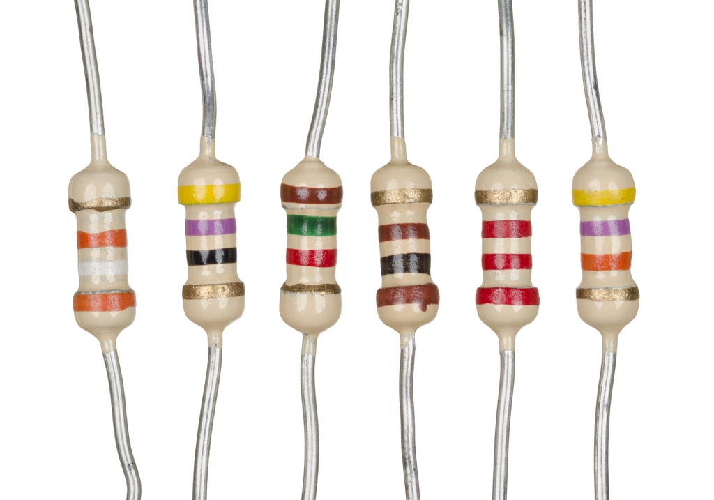

```python
YouTubeVideo('HsLLq6Rm5tU')
```

[video not shown]

# 3. Electromotive force

A conductor is able to sustain a steady current only if it is part of a closed loop: a **complete circuit**. Otherwise, charge would accumulate at one of the extremes of the circuit for no reason, creating a self-sustained electric field (which we now takes some energy). Therefore, for a current to exist, there must be some part in the circuit where moving charges gain some **potential energy**, similarly as pump lifts water to the top of a fountain. Such circuit element able to elevate charges to a higher potential is called a source of **electromotive force** $\mathcal E$ (emf).

We define an ideal source of emf by equating $\mathcal{E}$ and the voltage between its terminals

$$V_{ab}=\mathcal{E}$$

*Remarks*

- SI units: measured in volts (V)
- Sources of emf: chemical reactions in batteries, solar cells, electric dynamos...
- The voltage of a battery indicates its emf. Typical values: 1.5V, 5V, 9V...
- An ideal source of emf maintains a constant potential difference between its terminals regardless of the current through it. The external circuit is what fixes the current, although it cannot exceed the maximum current that the battery can deliver.
- Current flows from the positive pole to the negative pole along the circuit, but from negative to positive inside the battery thanks to the emf. In contrast, electrons travel from the negative to the positive pole along the circuit, and from positive to negative inside the battery.

```python
YouTubeVideo('w82aSjLuD_8')
```

[video not shown]

```python
# power sources for arduino
YouTubeVideo('Xe-Csmw9mb8')
```

[video not shown]

```python
YouTubeVideo('xEDyv_7tz8c')
```

[video not shown]

## 3.1 Real batteries

Real batteries present some internal resistance to a current, hence the potential difference across the battery is not exactly the same as the emf, $V_{ab}\leq \mathcal E$.

This effect is normally modeled by an ideal source in series with a resistor $r$

$$V_{ab}=\mathcal E- Ir$$

The emf is neither constant along the work life of the battery, as it usually decreases towards its end.

# 4. Magnetic force

The magnetic force is a fundamental interaction between **moving** charged particles.

The magnetic force applied on $q_1$ by $q_2$ with velocities $\vec v_1$ and $\vec v_2$ respectively is

$$\vec{F}_{1}=\frac{\mu_{0}}{4 \pi} \frac{q_1 q_{2}}{r^{2}} \vec{v}_1 \times\left(\vec{v}_{2} \times \frac{\vec{r}_{12}}{r}\right)$$$$\vec{r}_{12}=\vec{r}_{1}-\vec{r}_{2}$$$$r=\|\vec r_{12}\|$$

- $\frac{\mu_{0}}{4 \pi}=10^{-7} \mathrm{N} \cdot \mathrm{s}^{2} / \mathrm{C}^{2}$.
- $\mu_0$ is the magnetic **permeability** of vacuum (universal constant). $\mu_{0} =4 \pi \times 10^{-7} \mathrm{N} \cdot \mathrm{s}^{2} / \mathrm{C}^{2}=4 \pi \times 10^{-7} \mathrm{Wb} \mathrm{A} \cdot \mathrm{m}=4 \pi \times 10^{-7} \mathrm{T} \cdot \mathrm{m} / \mathrm{A}$
- one can prove that $\vec F_1=-\vec F_2$ (Newton's third law)

Recall **cross product** of vectors

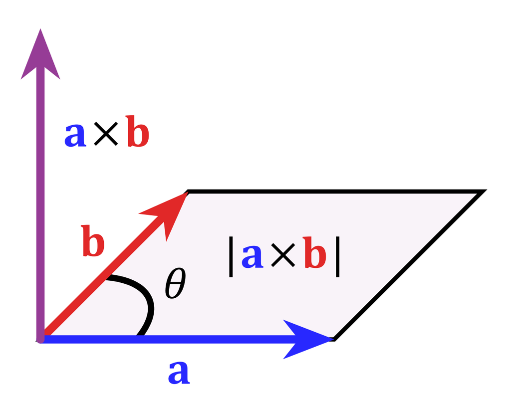

## 4.1 magnetic force between circuits

Force acting on circuit 2 caused by circuit 1

$$\mathbf{F}_{2}=\frac{\mu_{0}}{4 \pi} I_{1} I_{2} \oint_{1} \oint_{2} \frac{d \vec{l}_{2} \times\left[d \vec{l}_{1} \times\left(\vec{r}_{2}-\vec{r}_{1}\right)\right]}{\left|\vec{r}_{2}-\vec{r}_{1}\right|^{3}}$$

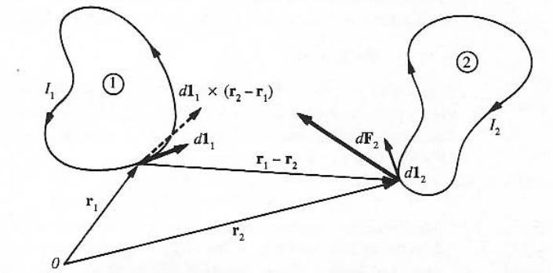

$\oint$ is the integral along the circuit (closed loop); $d \vec{l}$ is an infinitesimal length of wire, with direction given by the current density-

The previous expression simplifies when applied to two long parallel wires. The force per length of wire $L$ is simply

| $$\frac{F}{L}=\frac{\mu_{0} I I^{\prime}}{2 \pi r}$$ |
| --- |

# 5. Magnetic field

As we did with the electric interaction, we shall decompose the magnetic interaction in two parts: 1) a moving charge (or current) generates a magnetic field in its surroundings and 2) another moving charge (or current) in its surroundings 'feels' the presence of the magnetic field as a force acting on it.

Let's assume a **test charge** $q$ moving at velocity $\vec B$, the magnetic force follows the **Lorentz law**,

| $$\vec F=q \vec v \times \vec B$$ |
| --- |

$$\|\vec F\|=|q| \|\vec v\| \|\vec B\| sin\phi$$

Extension to a **wire** of length $l$ and current $I$, where $\vec l$ takes the direction of the the current density

| $$\vec{F}=I\vec{l} \times \vec{B}$$ |
| --- |

*Remarks*

- Like the electric field, the magnetic field is a vector field, which associates a vector to each point in space. $\vec B(\vec r): \mathbb{R}^3\rightarrow\mathbb{R}^3$.
- when the charge moves in the same direction as the magnetic field, the force is **zero**.
- the force is always **perpendicular** to the plane formed by the velocity and the magnetic field. Hence the **work** done by a magnetic force is **zero**. Invoking the work-energy theorem, a magnetic force **cannot change the kinetic energy** of a charge.
- If two charges with equal magnitude and opposite sign move in the same field with the same velocity , the forces have equal magnitude but opposite direction.
- The net force in the presence of both an electric and magnetic field is the vector sum: $\vec F=q (\vec E+\vec v \times \vec B)$.
- SI units, 1 **tesla** $=1 \mathrm{T}=1 \mathrm{N} / (\mathrm{A} \cdot \mathrm{m})$. Also popular, 1 **gauss** $1 \mathrm{G}=10^{-4} \mathrm{T}$.
- As for graphical representation purposes, a dot ($\cdot$) indicates a magnetic field vector directed out of the plane, whereas a cross ($\times$) representes a vector directed into the plane.

## 5.1 Right-hand rule

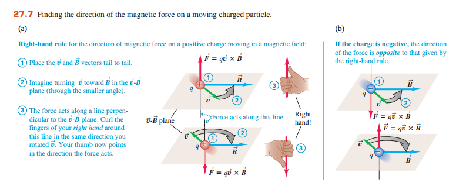

## 5.2 Magnetic field lines

The magnetic field is graphically represented by magnetic field lines. These are curves such that their **tangent** at any point align with the magnetic field.

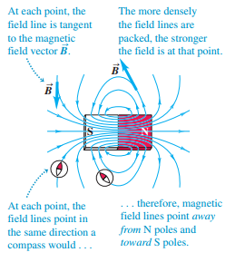

*Properties*:

- their **spacing** represents the magnitude of the magnetic field: the closer the lines, the stronger the field.
- At any given point the magnetic field is unique, hence field lines **never intersect**.
- Magnetic field lines are not “lines of force”, this is, they do **not** point in the direction of the magnetic force on a charge.
- Magnetic field lines do have the direction that a compass needle would point at each location

```python
#magnetic iron filings
YouTubeVideo('1PuL-Zh8PPk')
```

[video not shown]

## 5.3 Earth's magnetic field

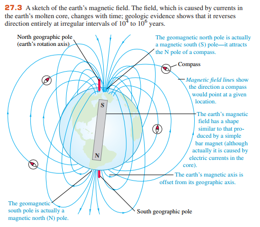

- The magnetic field of the Earth is of the order of 1G. 1T is actually a very intense magnetic field. Magnetic resonance imaging (MRI) employs strong magnetic fields $\approx 1.5 T$.

## 5.4 Elementary sources of magnetic field

### 5.4.1 Magnetic field of a point charge

Magnetic field of a charge located at $\vec r_1$ moving at velocity $\vec v$

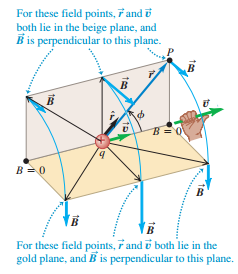

| circuit element at origin | arbitrary origin |
| --- | --- |
| $$\vec{B}(\vec r)=\frac{\mu_{0}}{4 \pi} \frac{q \vec{v} \times \hat{r}}{r^{2}}$$ $$\hat r\equiv \vec r/r$$ | $$ \vec{B}\left(\vec{r}_{2}\right)=\frac{\mu_{0}}{4 \pi} \frac{q\vec v\times\left(\vec{r}_{2}-\vec{r}_{1}\right)}{\|\vec{r}_{2}-\vec{r}_{1}\|^{3}}$$ |

- Similarly to the Coulomb field, the magnetic field is proportional to the charge q and the squared inverse of the distance $\propto 1/r^2$, but the direction is perpendicular to the plane formed by the velocity $\vec v$ and the field point $\vec r$.

### 5.4.2 Magnetic field of a circuit element

The total magnetic field created by several moving charges is the vector sum of the fields caused by the individual charges $d \vec{B}=\int d\vec B_{dQ}$. Hence it's straightforward to derive the **law of Biot and Savart**

| circuit element at origin | arbitrary origin |
| --- | --- |
| $$d \vec{B}=\frac{\mu_{0}}{4 \pi} \frac{I d \vec{l} \times \hat{r}}{r^{2}}$$ | $$d \vec{B}\left(\vec{r}_{2}\right)=\frac{\mu_{0}}{4 \pi} I_{1} \frac{d \vec{l} \times\left(\vec{r}_{2}-\vec{r}_{1}\right)}{\|\vec{r}_{2}-\vec{r}_{1}\|^{3}}$$ |

with $d\vec l$ being a vector with length $dl$ in the same direction as the current density in the conductor.

Integrating over the entire circuit

$$\vec{B}\left(\vec{r}_{2}\right)=\frac{\mu_{0}}{4 \pi} I_{1} \oint_{1} \frac{d \vec{l}_{1} \times\left(\vec{r}_{2}-\vec{r}_{1}\right)}{\left|\vec{r}_{2}-\vec{r}_{1}\right|^{3}}$$

The field lines go in circles around $d\vec l$, with direction given by the right-hand side rule.

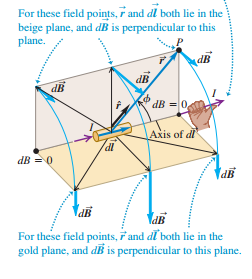

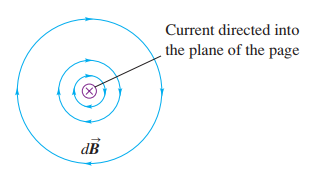

### 5.4.3 Magnetic field of an arbitrary density current

Bearing in mind that $Id\vec l=\vec J dV$, then

$$d \vec{B}\left(\vec{r}_{2}\right)=\frac{\mu_{0}}{4 \pi} \frac{\vec{J}\left(\vec{r}_{1}\right) \times\left(\vec{r}_{2}-\vec{r}_{1}\right)}{\left|\vec{r}_{2}-\vec{r}_{1}\right|^{3}} d V_{1}$$$$\vec{B}\left(\vec{r}_{2}\right)=\frac{\mu_{0}}{4 \pi} \int_{V} \frac{\vec{J}\left(\vec{r}_{1}\right) \times\left(\vec{r}_{2}-\vec{r}_{1}\right)}{\left|\vec{r}_{2}-\vec{r}_{1}\right|^{3}} d V_{1}$$

## 5.5 Important simple cases

long straight conducting wire

on the axis of a circular loop

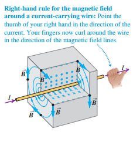

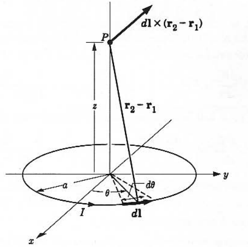

$B_{\theta}=\frac{\mu_{0} I}{2 \pi r}$

$B_{z}=\frac{\mu_{0} I a^{2}}{2\left(z^{2}+a^{2}\right)^{3 / 2}}$

Read and understand the derivation by yourself: Sears & Zemansky 28.3, 28.5

```python
YouTubeVideo('bq6IhapfucE')
```

[video not shown]

# 6. Magnetic flux

Analogously to the electric flux, the magnetic flux is a measure of how much magnetic field crosses a certain surface.

| $$\Phi_{B}=\int \vec{B} \cdot d \vec{A}=\int B \cos \phi d A$$ |
| --- |

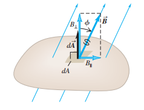

- The SI unit of magnetic flux is the **weber** (Wb) in honor of the German physicist Wilhelm Weber (1804–1891), $\mathrm{I} \mathrm{Wb}=1 \mathrm{T} \cdot \mathrm{m}^{2}$
- Geometrically, it quantifies how many magnetic field lines are crossing the surface

# 7. Gauss's law for magnetism

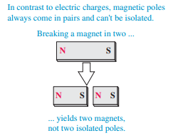

Experimentally, magnetic monopoles have never been observed. Thus,

| $$\oint \vec B \cdot d \vec A=0$$ |
| --- |

In other words: unlike electric field lines, magnetic field lines always draw **loops**, no endpoints.

One can also prove this result taking the divergence of the Biot-Savart law (advanced).

# 8. Ampere's circuital law

Ampere's circuital law tells us that the line integral around a **closed** path is proportional to the algebraic sum of the currents enclosed by the integration path

| $$\oint \vec B \cdot {d \vec{l}}=\mu_{0} I_{\mathrm{encl}}$$ |
| --- |

What does "currents enclosed" $ I_{\mathrm{encl}}$ mean?

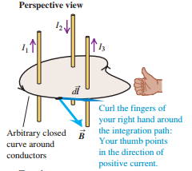

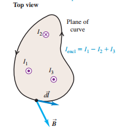

*Remarks*:

- This law is going to play a equivalent role to the **Gauss's law** for electrostatic fields.
- The shape of the path or the position of the wire inside are **irrelevant**.
- The closed path does not necessarily correspond to any physical circuit, neither a magnetic field line, it is just **imaginary**.
- The way in which we go around the closed path determines the sign of the current, simply using the **right-hand rule**.
- Even if $\oint \vec B \cdot {d \vec{l}}=0$, it does not necessarily imply that $\vec B=0$, only that the currents enclosed add up to 0.

## 8.1 Using Ampere's law to calculate magnetic fields

Amperes' law is useful in situations with high degree of **symmetry** so that the integral is trivial to compute.

*Simplest case*: long straight wire

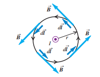

$$ \oint \vec B \cdot {d \vec{l}}=B\oint dl=B(2\pi r)={\mu_0}I\implies B=\frac{\mu_0 I}{2\pi r}$$

Important: Ampere's law gives you the **module** of the field, but the direction is presumed to be known already!

**Solenoid**: a helical winding of wire on a cylinder or toroid. When the solenoid is long compared to its cross-sectional diameter and the coils are tightly wound, the field inside the solenoid can be approximated by a uniform magnetic field, while the external field is almost negligible.

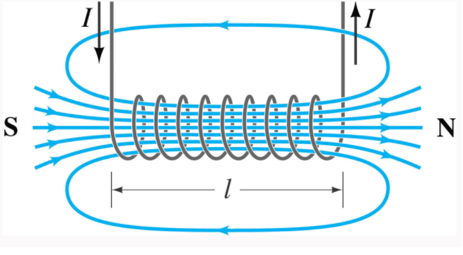

```python
YouTubeVideo('BbmocfETTFo')
```

[video not shown]

- Long solenoid with $n$ turns per unit length

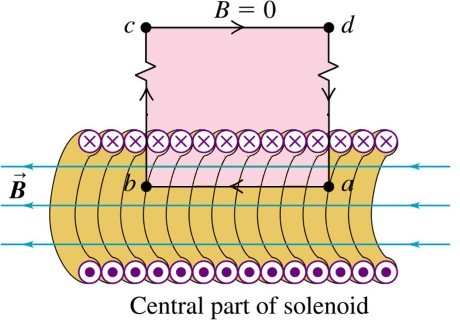

  $$ \oint \vec B \cdot {d \vec{l}}=BL=\mu_{0} n L I\implies B=\mu_{0} n I$$
- Toroidal solenoid with N turns

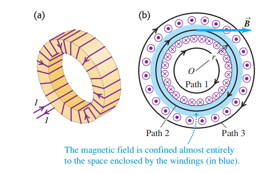

$$ \oint \vec B \cdot {d \vec{l}}=B(2\pi r)=\mu_{0} N I\implies B=\frac{\mu_{0} N I}{2\pi r}$$

# 9. Magnetic dipole

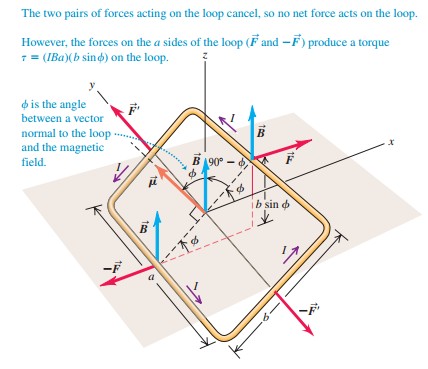

The net force on a current loop in a uniform magnetic field is zero, yet there exists a torque that forces the loop to rotate. The net torque acting on a conducting loop is:

$$\vec{\tau}=\vec{\mu} \times \vec{B}$$

where $$\vec\mu=I\vec A$$ is called magnetic dipole moment or **magnetic moment**. More generally, one can show that

$$\vec{\mu}=\frac{1}{2} I \oint_{C} \mathbf{r} \times d \mathbf{l}$$

We can associate a magnetic energy as

$$U=-\vec{\mu} \cdot \vec{B}=-\mu B \cos \phi$$

*Remarks*

- The right-hand rule determines the direction of the magnetic moment of a current-carrying loop.
- This result is analogous to the torque exerted by an electric field on an electric dipole.

magnetic moment of a solenoid (electromagnets) $$\vec\mu=N I \vec A $$ $$\tau=N I A B \sin \phi$$

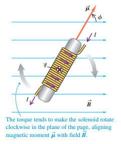

```python
# Basic DC motor
YouTubeVideo('voHz6sxwQ2Q')
```

[video not shown]

```python
## How DC motors work
YouTubeVideo('LAtPHANEfQo')
```

[video not shown]

```python
## more on how DC motors work
YouTubeVideo('GQatiB-JHdI')
```

[video not shown]

```python
# dipole-dipole repulsion
YouTubeVideo('aPkqflLmjrw')
```

[video not shown]

```python
# How MRI works
YouTubeVideo('nFkBhUYynUw')
```

[video not shown]

# 10. Magnetic materials

**Magnetization** is defined as the number of atomic/molecular moments per unit volume in a certain material.

$$\vec{M}=\frac{{{d\vec\mu}}}{dV}$$

- **Paramagnetic materials**: atomic moments tend to align with some external magnetic field. The resulting magnetization creates an internal magnetic field that **reinforces** the externally applied magnetic field.
- **Diagmagnetic materials**: **induced** atomic moments tend to align in opposite direction with some external magnetic field. The resulting magnetization creates an internal magnetic field that **weakens** the externally applied magnetic field.

Inside of these materials, many times we can simply replace $\mu_0$ in our previous equations by

$$\mu=\mu_{r} \mu_{0}$$

where $\mu$ is the **permeability** of the material and $\mu_r$ is the **relative permeability**.

We can also define the **magnetic susceptibility**

$$\chi_m=\mu_r-1$$

| Material | $\chi_m$(T=20º) |
| --- | --- |
| Platinum | 26 |
| Aluminum | 2.2 |
| Sodium | 0.72 |
| Oxygen gas | 0.19 |
| Bismuth | -16.6 |
| Mercury | - 2.9 |
| Silver | -2.6 |
| Carbon (diamond) | -2.1 |
| Lead | -1.8 |
| Sodium chloride | -1.4 |
| Copper | -1.0 |

**Ferromagnetism**: magnetic moments tend to align **even if there is no externally applied magnetic field**. Their behavior is therefore **nonlinear**.

Magnets are actually ferromagnetic.

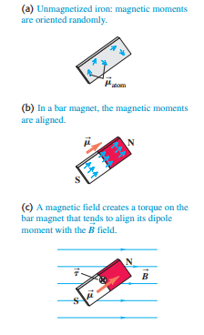

```python
# magnetization by friction
YouTubeVideo('znQgTv3spnE')
```

[video not shown]

# 11. The Hall effect

Let's apply a magnetic field on a conductor in the form of a flat strip.

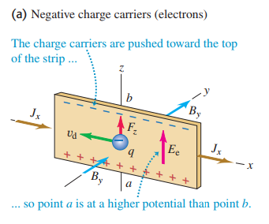

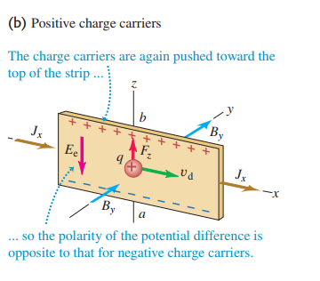

1. The magnetic field deviates the trajectory of electrons causing accumulation at one of the edges of the strip, leaving an excess positive charge at the opposite edge.
2. Accumulation continues until the resulting transverse electrostatic field is large enough to counteract the external magnetic field.
3. The final electric field implies there exists a potential difference between the opposite edges of the strip (distance $d$), called the **Hall voltage** or **Hall emf**.

$$e E_{z}+e v_{\mathrm{d}} B_{y}=0$$$$J_{x}=n e v_{\mathrm{d}}$$

,

$$-e E_{z}-e v_{\mathrm{d}} B_{y}=0$$$$J_{x}=-n e v_{\mathrm{d}}$$

,

Both situations can be summarized as follows

$$q E_{z}+q v_{\mathrm{d}} B_{y}=0$$$$J_{x}=n q v_{\mathrm{d}}$$

Then

$$n q=\frac{-J_{x} B_{y}}{E_{z}}=\frac{-J_{x} B_{y} d}{V_{ab}}$$

*Remarks*

- The sign of the Hall voltage crucially depends on the sign of the charge carriers: $V_{ab}>0$ for electrons.
- Discovered by the American physicist Edwin Hall in 1879

```python
#Hall effect
YouTubeVideo('wpAA3qeOYiI')
```

[video not shown]

```python
# Hall effect sensors for arduino
YouTubeVideo('42qNfPOYlR8')
```

[video not shown]

# Appendix

```python
#Magnetic toys
YouTubeVideo('kA_hw_lY-OY')
```

[video not shown]